# CSCI E-63C: Week 12 Homework

# Preface

This week problem set will explore behavior of support vector classifiers and SVMs (following the distinction made in ISLR) on WiFi localization dataset from UCI ML archive. We worked with it on multiple occasions already (most recently two weeks ago, when evaluating the performance of logistic regression, discriminant analysis and KNN on those data). Same way as we did it two weeks ago, we are going to convert the four-level outcome provided in the dataset to the binary one, indicating localization at the third room vs amywhere else:

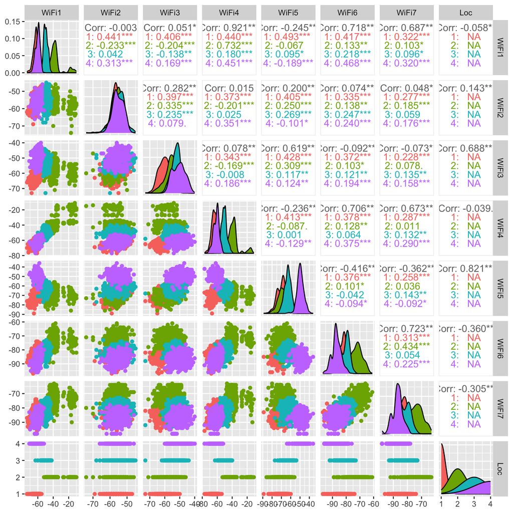

```r
wifiLocDat <- read.table("wifi_localization.txt",sep="\t")
colnames(wifiLocDat) <- c(paste0("WiFi",1:7),"Loc")
ggpairs(wifiLocDat,aes(colour=factor(Loc)))
```

```r
wifiLocDat[,"Loc3"] <- factor(wifiLocDat[,"Loc"]==3)
wifiLocDat <- wifiLocDat[,colnames(wifiLocDat)!="Loc"]
dim(wifiLocDat)
```

```
## [1] 2000    8
```

```r
summary(wifiLocDat)
```

```
##      WiFi1            WiFi2            WiFi3            WiFi4
##  Min.   :-74.00   Min.   :-74.00   Min.   :-73.00   Min.   :-77.00
##  1st Qu.:-61.00   1st Qu.:-58.00   1st Qu.:-58.00   1st Qu.:-63.00
##  Median :-55.00   Median :-56.00   Median :-55.00   Median :-56.00
##  Mean   :-52.33   Mean   :-55.62   Mean   :-54.96   Mean   :-53.57
##  3rd Qu.:-46.00   3rd Qu.:-53.00   3rd Qu.:-51.00   3rd Qu.:-46.00
##  Max.   :-10.00   Max.   :-45.00   Max.   :-40.00   Max.   :-11.00
##      WiFi5            WiFi6            WiFi7           Loc3
##  Min.   :-89.00   Min.   :-97.00   Min.   :-98.00   FALSE:1500
##  1st Qu.:-69.00   1st Qu.:-86.00   1st Qu.:-87.00   TRUE : 500
##  Median :-64.00   Median :-82.00   Median :-83.00
##  Mean   :-62.64   Mean   :-80.98   Mean   :-81.73
##  3rd Qu.:-56.00   3rd Qu.:-77.00   3rd Qu.:-78.00
##  Max.   :-36.00   Max.   :-61.00   Max.   :-63.00
```

```r
head(wifiLocDat)
```

```
##   WiFi1 WiFi2 WiFi3 WiFi4 WiFi5 WiFi6 WiFi7  Loc3
## 1   -64   -56   -61   -66   -71   -82   -81 FALSE
## 2   -68   -57   -61   -65   -71   -85   -85 FALSE
## 3   -63   -60   -60   -67   -76   -85   -84 FALSE
## 4   -61   -60   -68   -62   -77   -90   -80 FALSE
## 5   -63   -65   -60   -63   -77   -81   -87 FALSE
## 6   -64   -55   -63   -66   -76   -88   -83 FALSE
```

Here we will use SVM implementation available in the library `e1071` to fit classifiers with linear and radial (polynomial for extra points) kernels and to compare their relative performances; we will also compare their performance to that of random forest and KNN.

# Problem 1 (20 points): support vector classifier (i.e. using linear kernel)

- Use `svm()` function from library `e1071` with `kernel="linear"` to fit classifier (see e.g. ISLR Ch.9.6.1) to the entire WiFi localization dataset setting parameter `cost` to 0.001, 1, 1000 and 1 mln.

```r
for (c in c(0.001, 1, 1000, 1e6)){
svmres = svm(Loc3 ~ ., data = wifiLocDat, kernel = 'linear', cost = c)
print(paste0("Cost = ", c, ", Number of Support Vectors:", svmres$tot.nSV))
}
```

```
## [1] "Cost = 0.001, Number of Support Vectors:1013"
## [1] "Cost = 1, Number of Support Vectors:1000"
## [1] "Cost = 1000, Number of Support Vectors:1015"
## [1] "Cost = 1e+06, Number of Support Vectors:450"
```

- Describe how those changes in the `cost` parameter affect (1) the model fitting process (**hint**: the difficulty of the underlying optimization problem increases with cost – can you explain why?) and (2) its outcome (e.g. how does the number of support vectors change with `cost`?). What are the implications?

*As the cost parameter increases, the model is fit with a narrower margin. Between cost = 0.001 and 1000, this did not result in a very large difference in the number of support vectors. However, when the cost was increased to 1e6, the number of support vectors decreased significantly.*

- Please explain explicitly (ever so briefly is fine) why the change in `cost` value impacts number of support vectors found. (**hint**: there is an answer in ISLR.)

*The cost value represents the cost of a violation to the margin, so a larger cost value corresponds with a narrower margin and a smaller cost value corresponds with a wider margin. A wider margin results in more support vectors.*

- Use `tune()` function from library `e1071` (see ISLR Ch.9.6.1 for details and examples of usage) to determine approximate value of the cost that yields the lowest error in cross-validation employed by `tune`. Please use the grid for the cost parameter spanning the range between 0.1 and 100. Note that for the cost range spanning orders of magnitude it would be a good idea to use (approximately) logarithmic grid density – e.g. something like 0.1, 0.3, 1, 3, 10…, or 0.1, 0.2, 0.5, 1, … *etc*.). When you find the (approximately) optimal cost, you may rerun `tune()` on a denser grid just around that value to get a more accurate result (for your own enjoyment, this is not required).

```r
tune = tune(svm, Loc3 ~ ., data = wifiLocDat, kernel = 'linear',
            ranges = list(cost = c(0.1, 0.3, 1, 3, 10, 30, 100)))
summary(tune)
```

```
##
## Parameter tuning of 'svm':
##
## - sampling method: 10-fold cross validation
##
## - best parameters:
##  cost
##    10
##
## - best performance: 0.2265
##
## - Detailed performance results:
##    cost  error dispersion
## 1   0.1 0.2495 0.01877498
## 2   0.3 0.2380 0.02720294
## 3   1.0 0.2290 0.03414023
## 4   3.0 0.2270 0.03172801
## 5  10.0 0.2265 0.03223611
## 6  30.0 0.2265 0.03223611
## 7 100.0 0.2265 0.03223611
```

```r
paste0("Best Cost Parameter: ", tune$best.parameters)
```

```
## [1] "Best Cost Parameter: 10"
```

- Now setup a resampling procedure by repeatedly splitting the entire dataset into training and test subsets. In each resampling iteration (1) use just the *training* subset to fully `tune` cost value (in other words, we are now asking `tune` to perform all of its own crossvalidation splits and to identify the “best” cost parameter value using training data only); then (2) use the test subset (i.e. the part of the data that was *truly* unseen before, not even for choosing the model’s hyperparameter – cost in this case) to estimate the classification test error of the best model tuned on the training subset. Draw distributions of the test errors (boxplots are fine) reported by `tune` for the best models (i.e. obtained through cross-validation on the training set) and those computed for the selected best model on the actual test set, discuss.

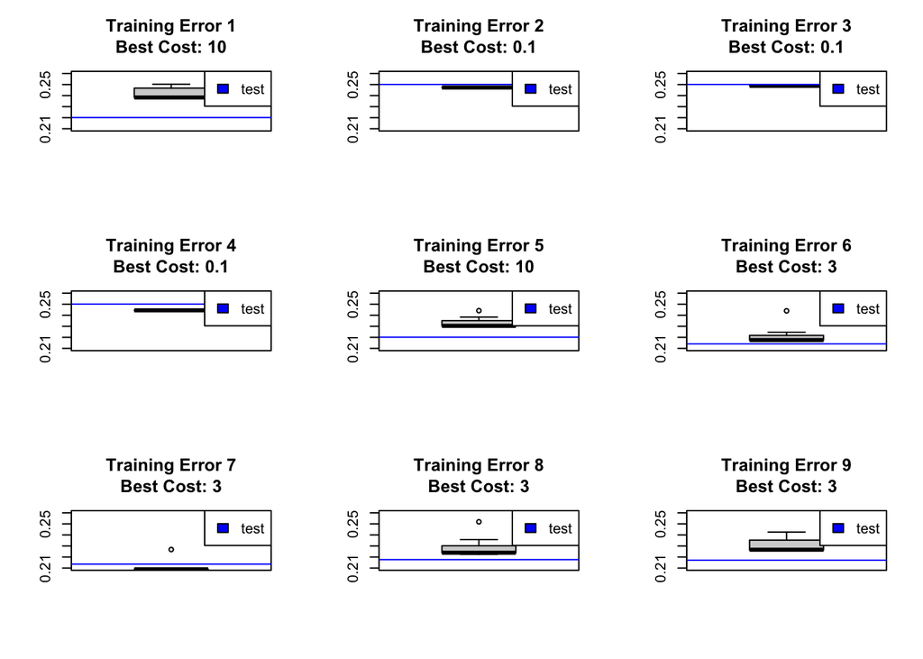

```r
par(mfrow = c(3, 3))
for (t in 1:9){
sample = sample(c(TRUE, FALSE), nrow(wifiLocDat), replace = TRUE, prob = c(0.7, 0.3)) #70/30 split

train = wifiLocDat[sample, ]
test = wifiLocDat[-sample, ]

tunecv = tune(svm, Loc3 ~ ., data = train, kernel = 'linear',
            ranges = list(cost = c(0.1, 0.3, 1, 3, 10, 30, 100)))

bestm = tunecv$best.model
pred = predict(bestm, newdata = test)

conf = confusionMatrix(pred, test$Loc3)

testerr = 1 - conf$overall[1]

boxplot(tunecv$performances$error, main = paste0("Training Error ", t, "\nBest Cost: ", tunecv$best.parameters), ylim = c(0.21, 0.26))
abline(h = testerr, col = 'blue')
legend(legend = c('test'), fill = 'blue', "topright")

}
```

# Problem 2 (10 points): comparison to random forest

- Fit random forest classifier on the entire WiFi localization dataset using default parameters.

```r
rf = randomForest(Loc3 ~ ., wifiLocDat)
rf
```

```
##
## Call:
##  randomForest(formula = Loc3 ~ ., data = wifiLocDat)
##                Type of random forest: classification
##                      Number of trees: 500
## No. of variables tried at each split: 2
##
##         OOB estimate of  error rate: 1.45%
## Confusion matrix:
##       FALSE TRUE class.error
## FALSE  1483   17  0.01133333
## TRUE     12  488  0.02400000
```

- Obtain resulting misclassification error as reported by the confusion matrix in random forest output.
- Explain why error reported in random forest confusion matrix represents estimated test (as opposed to train) error of the procedure.

*Random forest reports out-of-bag error, which uses the subset of data that was not used in fitting the model. The dataset for the bagged tree is like the training set and then the out-of-bag error is like the testing set.*

- Compare resulting test error to that for support vector classifier obtained above and discuss results of such comparison.

For this problem, there is no need to set up an “external” resampling loop, you can use the whole dataset.

# Problem 3 (10 points): Comparison to cross-validation tuned KNN predictor

- Use convenience wrapper `tune.knn` provided by the library `e1071` on the *entire* dataset to determine optimal value for the number of the nearest neighbors ‘k’ to be used in KNN classifier. Consider our observations from week 10 problem set when choosing range of values of `k` to be evaluated by `tune.knn`.

```r
knntn = tune.knn(y = wifiLocDat$Loc3, x = wifiLocDat[1:7], data = wifiLocDat, k = c(1, 3, 5, 10, 20, 50, 100))

summary(knntn)
```

```
##
## Parameter tuning of 'knn.wrapper':
##
## - sampling method: 10-fold cross validation
##
## - best parameters:
##  k
##  3
##
## - best performance: 0.012
##
## - Detailed performance results:
##     k  error  dispersion
## 1   1 0.0125 0.007905694
## 2   3 0.0120 0.005868939
## 3   5 0.0130 0.009486833
## 4  10 0.0175 0.009501462
## 5  20 0.0185 0.010554093
## 6  50 0.0210 0.011254629
## 7 100 0.0220 0.011832160
```

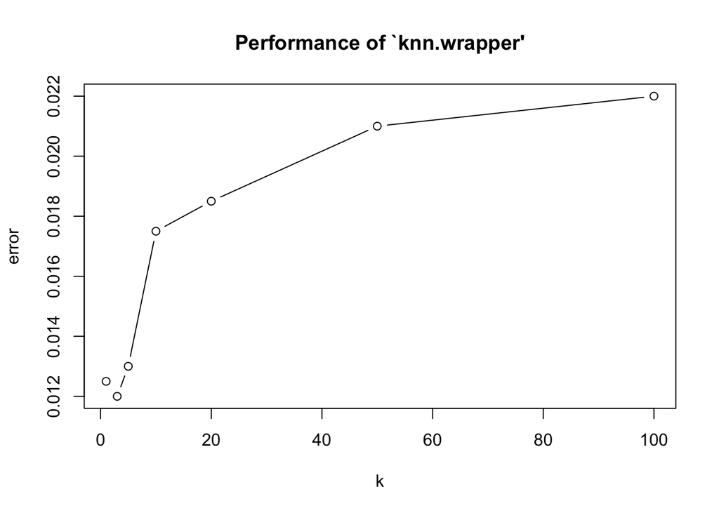

```r
plot(knntn)
```

*k = 3 shows the lowest error.*

- Then setup a hierachical resampling procedure similar to the one used in Problem 1 for support vector classifier: the procedure will repeatedly (1) split WiFi localization dataset into training and test; (2) use `tune.knn` on just the training data to determine optimal `k`; and then (3) use `k` estimated by `tune.knn` from the training subset to make KNN classifications on the test subset. Report and discuss distributions of test errors from this procedure, as well as the distributions of the selected values of `k` (since we are now tuning on a new, randomly selected training subset every time, the selected “best” values for $k$ *might* be different!). Compare the test errors to those obtained earlier when using random forest and support vector classifier.

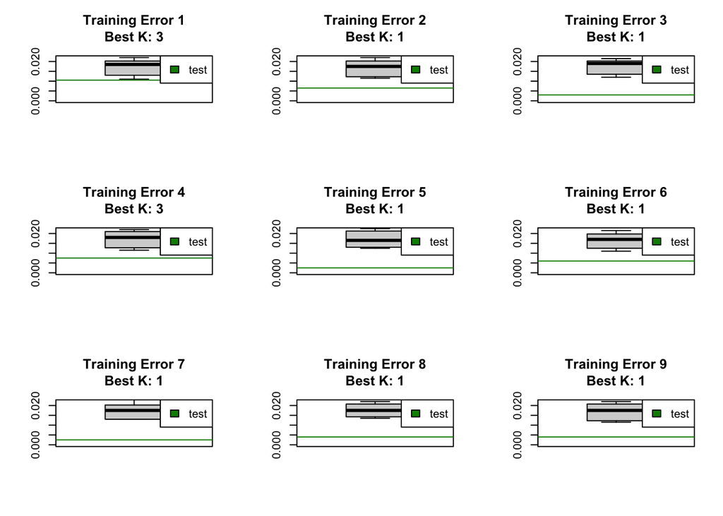

```r
par(mfrow = c(3, 3))
for (t in 1:9){
sample = sample(c(TRUE, FALSE), nrow(wifiLocDat), replace = TRUE, prob = c(0.7, 0.3)) #70/30 split


train = wifiLocDat[sample, ]
test = wifiLocDat[-sample, ]

train$Loc3 = as.numeric(train$Loc3) #convert to numeric to avoid knn error
test$Loc3 = as.numeric(test$Loc3)

knncv = tune.knn(y = wifiLocDat$Loc3, x = wifiLocDat[1:7], data = wifiLocDat, k = c(1, 3, 5, 10, 20, 50, 100))

bestm = knncv$best.model
bestk = bestm$k
pred = knn(train = train, test = test, k = bestk, cl = train$Loc3)

conf = confusionMatrix(as.factor(pred), as.factor(test$Loc3))

testerr = 1 - conf$overall[1]

boxplot(knncv$performances$error, main = paste0("Training Error ", t, "\nBest K: ", knncv$best.parameters), ylim = c(0, 0.022))
abline(h = testerr, col = 'green4')
legend(legend = c('test'), fill = 'green4', "topright")

}
```

# Problem 4 (20 points): SVM with radial kernel

## Sub-problem 4a (10 points): impact of rate parameter $\gamma$ on classification surface

- *Plot* SVM model fit to the WiFi localization dataset using (for the ease of plotting) *only the first and the second attributes* as predictor variables, `kernel="radial"`, `cost=10` and `gamma=5` (see ISLR Ch.9.6.2 for an example of that done with a simulated dataset).

```r
radsvm = svm(Loc3 ~ WiFi1 + WiFi2, data = wifiLocDat, kernel = 'radial', cost = 10, gamma = 5)
summary(radsvm)
```

```
##
## Call:
## svm(formula = Loc3 ~ WiFi1 + WiFi2, data = wifiLocDat, kernel = "radial",
##     cost = 10, gamma = 5)
##
##
## Parameters:
##    SVM-Type:  C-classification
##  SVM-Kernel:  radial
##        cost:  10
##
## Number of Support Vectors:  294
##
##  ( 173 121 )
##
##
## Number of Classes:  2
##
## Levels:
##  FALSE TRUE
```

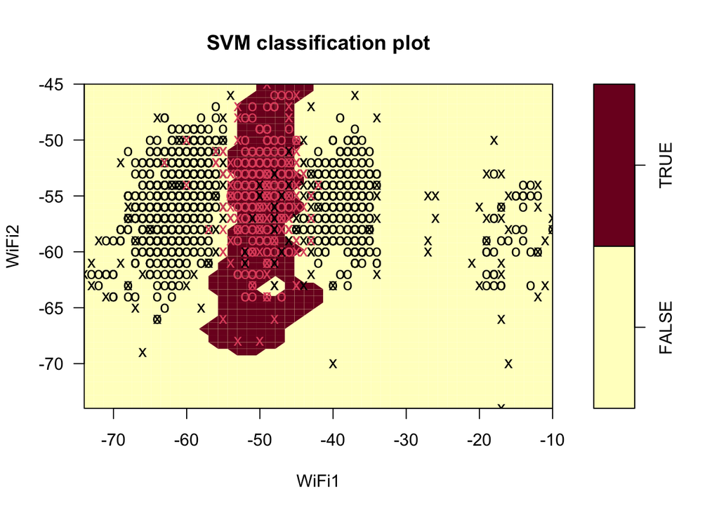

```r
plot(radsvm, wifiLocDat, WiFi2 ~ WiFi1)
```

In the resulting plot, you should be able to see the yellow and brown regions separated by the classification boundary as computed by this model.

- Also produce the same kinds of plots using 0.5 and 50 as the values for `gamma`. Compare classification boundaries in these three plots and describe how they are impacted by the change in the value of `gamma`.  
  Can you trace it back to the role of the parameter `gamma` in the equation for the radial kernel in ISLR?

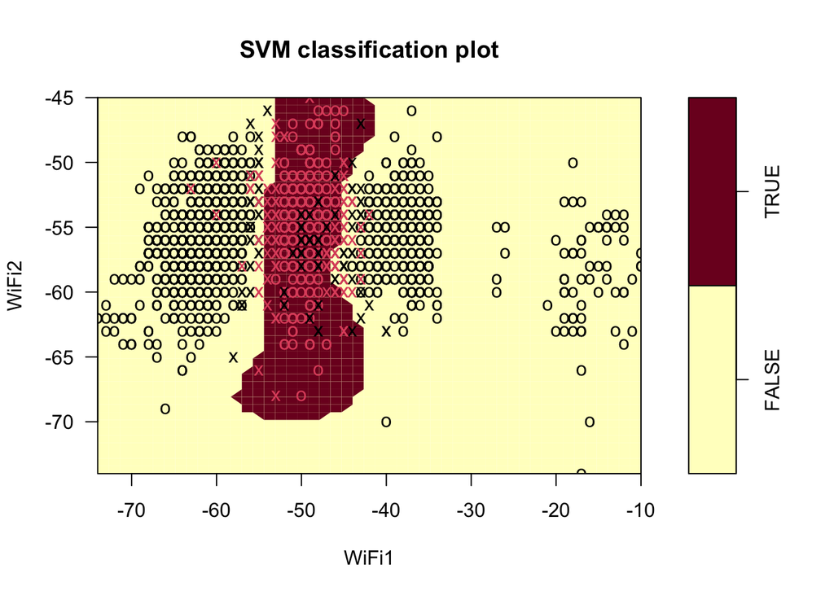

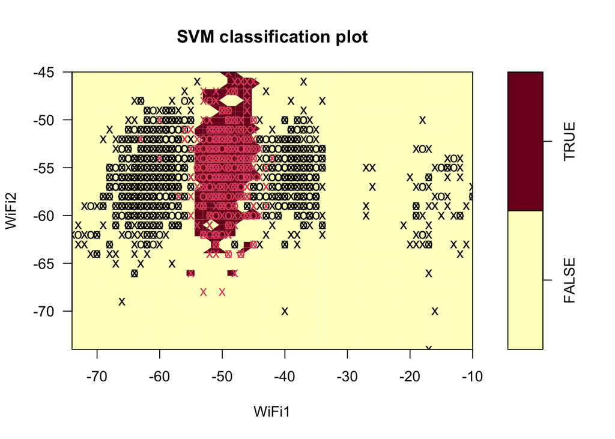

```r
for (g in c(0.5, 50)){
radsvm = svm(Loc3 ~ WiFi1 + WiFi2, data = wifiLocDat, kernel = 'radial', cost = 10, gamma = g)
plot(radsvm, wifiLocDat, WiFi2 ~ WiFi1)
}
```

*The boundary for classification = TRUE gets smaller as gamma increases. In the radial kernel equation, increasing gamma indicates that only very close points matter, resulting in the smaller boundary.*

## Sub-problem 4b (10 points): test error for SVM with radial kernel

- In a way similar to how it was done earlier for the support vector classifier (and KNN), set up a resampling process that will repeatedly: (1) split the entire dataset (using all attributes as predictors) into training and test subsets; (2) in each iteration use `tune` function to determine the optimal values of `cost` *and* `gamma`; then (3) calculate the test error using these values of `cost` and `gamma` (on the actual test subset). Consider what you have learned above about the effects of the parameters `cost` and `gamma` to decide on the starting ranges of their values to be evaluated by `tune`.

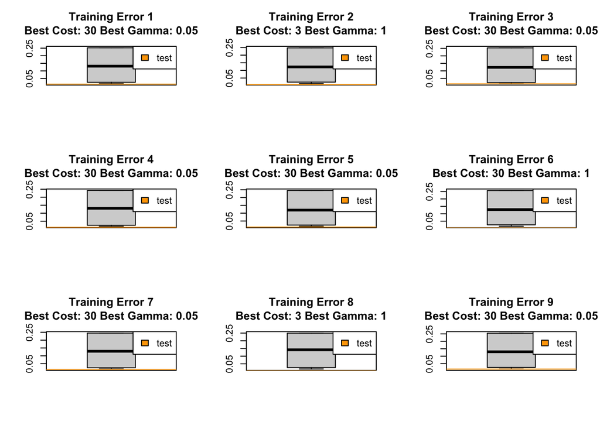

```r
par(mfrow = c(3, 3))
for (t in 1:9){
sample = sample(c(TRUE, FALSE), nrow(wifiLocDat), replace = TRUE, prob = c(0.7, 0.3)) #70/30 split

train = wifiLocDat[sample, ]
test = wifiLocDat[-sample, ]

tunecvr = tune(svm, Loc3 ~ ., data = train, kernel = 'radial',
            ranges = list(cost = c(0.1, 0.3, 1, 3, 10, 30, 100), gamma = c(0.05, 1, 5, 10, 50)))

bestm = tunecvr$best.model
pred = predict(bestm, newdata = test)

conf = confusionMatrix(pred, test$Loc3)

testerr = 1 - conf$overall[1]

boxplot(tunecvr$performances$error, main = paste0("Training Error ", t, "\nBest Cost: ", tunecvr$best.parameters$cost, " Best Gamma: ", tunecvr$best.parameters$gamma ))
abline(h = testerr, col = 'orange')
legend(legend = c('test'), fill = 'orange', "topright")

}
```

- Additionally, experiment with different sets of those values and discuss the results in your solution. Discuss how you would go about selecting the ranges for tuning starting from scratch.

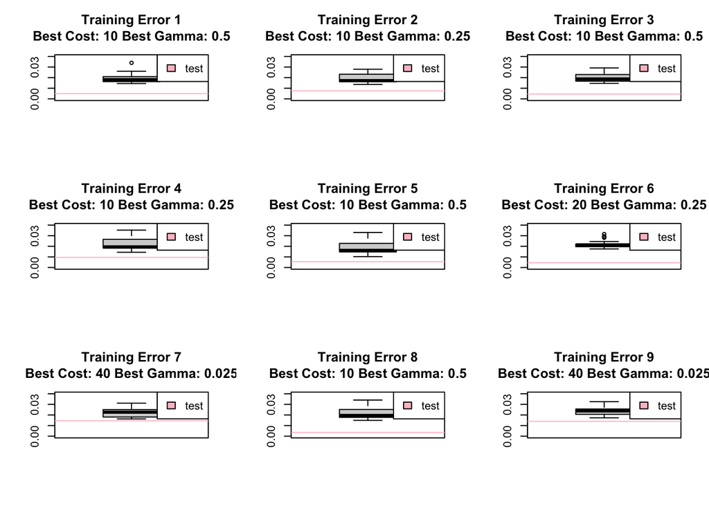

```r
par(mfrow = c(3, 3))
for (t in 1:9){
sample = sample(c(TRUE, FALSE), nrow(wifiLocDat), replace = TRUE, prob = c(0.7, 0.3)) #70/30 split

train = wifiLocDat[sample, ]
test = wifiLocDat[-sample, ]

tunecvr = tune(svm, Loc3 ~ ., data = train, kernel = 'radial',
            ranges = list(cost = c(10, 20, 30, 40), gamma = c(0.01, 0.025, 0.05, 0.25, 0.5, 1, 1.5)))

bestm = tunecvr$best.model
pred = predict(bestm, newdata = test)

conf = confusionMatrix(pred, test$Loc3)

testerr = 1 - conf$overall[1]

boxplot(tunecvr$performances$error, main = paste0("Training Error ", t, "\nBest Cost: ", tunecvr$best.parameters$cost, " Best Gamma: ", tunecvr$best.parameters$gamma ), ylim = c(0, 0.04))
abline(h = testerr, col = 'pink')
legend(legend = c('test'), fill = 'pink', "topright")

}
```

- Present resulting test error graphically and compare them to those obtained in the previous problems with support vector classifier (i.e. with linear kernel), with random forest, and with KNN. Discuss results of these comparisons.

# Extra 5 points problem: SVM with polynomial kernel

Repeat what was you have done in Problem 4 (plots of decision boundaries for various interesting values of tuning parameters and test error for their best values estimated from training data) using `kernel="polynomial"`. Determine ranges of `coef0`, `degree`, `cost` and `gamma` to be evaluated by `tune`. Present and discuss resulting test error and how it compares to the errors of linear and radial kernels and also of random forest and KNN models.